# FDI ve Enflasyonun Ekonomik Buyume Uzerine Etkisi

G20 Ulkeleri Panel Veri Analizi (2014-2022) — Aciklamali Surum

Panel Veri Projesi

2026

# 1 Arastirma Sorusu ve Motivasyon

## 1.1 Ne Soruyoruz?

> **“Yabanci dogrudan yatirim (FDI) ve enflasyon, G20 ulkelerinin ekonomik buyumesini ne yonde ve ne olcude etkiliyor?”**

## 1.2 Neden Bu Soruyu Soruyoruz?

**FDI icin:** Gelismekte olan ulke literaturunde FDI, teknoloji transferi, istihdam ve verimlilik artisi yoluyla buyumeyi tetikleyen bir motor olarak gosterilir. Peki G20 gibi hem gelismis hem gelismekte olan ulkelerin karisik oldugu bir grupta bu iliskisi gecerli midir? Bu ulkeler zaten derin sermaye piyasalarina ve ileri teknolojiye sahip — FDI’nin ekstra katki saglayip saglamadigi sorgulanabilir.

## 1.3 Temel Model

$$gdp\_growth_{it} = \alpha_i + \beta_1
\cdot ihs\_fdi_{it} + \beta_2 \cdot inflation_{it} + \sum_{k=3}^{7}
\beta_k X_{kit} + \gamma_j \cdot Kukla_{jit} +
\epsilon_{it}$$

Burada $\alpha_i$ ulkeye ozgu sabit etki (gozlemlenemeyen heterojenite: kurumsal yapi, cografya, tarih), $i$ ulke, $t$ yil indeksidir.

Degisken Tanimi, Birimi ve Teorik Beklenti

| Degisken | Aciklama | Birim | Rol | Beklenti |
| --- | --- | --- | --- | --- |
| gdp_growth | GDP buyume orani — bagimli degisken | % | Bagimli | — |
| ihs_fdi | FDI net giris — IHS donusumlu | IHS(USD) | Ana Aciklayici | Pozitif? |
| inflation | Enflasyon — GDP deflator | % | Ana Aciklayici | Negatif |
| inv | Yurtici yatirim — Gross Capital Formation | % GDP | Kontrol | Pozitif |
| export | Ihracat | % GDP | Kontrol | Pozitif |
| import_ | Ithalat | % GDP | Kontrol | Belirsiz |
| pop_growth | Nufus buyume orani | % | Kontrol | Belirsiz |
| ln_gdp | Ekonomi buyuklugu — log donusumlu | log(USD) | Kontrol | Pozitif |
| D_COVID | COVID-19 soku: 2020 = 1 | 0/1 | Kukla | Negatif |
| D_POST_COVID | COVID sonrasi: 2021-22 = 1 (M2) | 0/1 | Kukla-M2 | Pozitif |
| D_RECOVERY | Mekanik toparlanma: 2021 = 1 (M3) | 0/1 | Kukla-M3 | Pozitif |
| D_2022 | Ukrayna/Enerji krizi: 2022 = 1 (M3) | 0/1 | Kukla-M3 | Belirsiz |

# 2 Veri: Kaynak ve Neden Bu Donem?

**Kaynak:** World Bank — World Development Indicators (WDI).

**Orneklem:** 19 G20 ulkesi (Isvicre G20 uyesi olmadigi icin analize dahil edilmemistir), 2014-2022 donemi. Panel **dengeli (balanced)**: **19 ulke × 9 yil = 171 gozlem.**

2013 oncesini dahil etmedik cunku: (1) Rusya’nin 2014 Ukrayna gerginligi yapisal kirilma yaratti, (2) 2008-2013 kuresel mali kriz sonrasi toparlanma heterojenligi, (3) 2023 verisinde FDI raporlama gecikmesi.

```r
library(readxl); library(dplyr); library(tidyr); library(stringr)
library(ggplot2); library(plm); library(lmtest); library(sandwich)
library(knitr); library(kableExtra); library(gridExtra)

World_Development_Indicators <- read_excel("World Development Indicators.xlsx")
data <- World_Development_Indicators

# Not: Isvicre G20 uyesi olmadigi icin listeden cikarilmistir
ulkeler <- c("Argentina","Australia","Brazil","China","France",
             "Germany","India","Indonesia","Italy","Japan",
             "Korea, Rep.","Mexico","Netherlands","Russian Federation",
             "Saudi Arabia","Spain","Turkiye",
             "United Kingdom","United States")

yil_sutunlari <- names(data)[grepl("\\[YR201[4-9]\\]|\\[YR202[0-2]\\]",
                                    names(data))]
hedef_seriler <- c(
  "GDP growth (annual %)"                                      = "gdp_growth",
  "Foreign direct investment, net inflows (BoP, current US$)" = "fdi",
  "Inflation, GDP deflator (annual %)"                        = "inflation",
  "Gross capital formation (% of GDP)"                        = "inv",
  "Exports of goods and services (% of GDP)"                  = "export",
  "Imports of goods and services (% of GDP)"                  = "import_",
  "Population growth (annual %)"                              = "pop_growth",
  "GDP (current US$)"                                         = "gdp"
)
```

# 3 Eksik Veri Analizi

## 3.1 Neden Yapiyoruz?

Panel veri analizinde eksik gozlemler iki kritik soruna yol acar: (1) **Dengesiz Panel Riski** — bazı ulkeler bazı yillarda yoksa within tahminci sapma gosterebilir, (2) **Secim Sapmasi Riski** — eksiklik rastgele degilse sistematik hata olusur. Bu nedenle analiz baslamadan kontrol edilmesi zorunludur.

```r
data_clean <- data %>%
  filter(`Country Name` %in% ulkeler, `Series Name` %in% hedef_seriler) %>%
  mutate(across(contains("YR"), ~ na_if(as.character(.), ".."))) %>%
  mutate(across(contains("YR"), as.numeric))

yil_sutunlari_v1 <- names(data_clean)[grepl("YR201[4-9]|YR202[0-2]",
                                             names(data_clean))]
eksik_ozet <- data_clean %>%
  select(`Series Name`, all_of(yil_sutunlari_v1)) %>%
  group_by(`Series Name`) %>%
  summarise(toplam   = n() * length(yil_sutunlari_v1),
            eksik    = sum(is.na(across(all_of(yil_sutunlari_v1)))),
            oran_pct = round(eksik / toplam * 100, 1), .groups = "drop") %>%
  arrange(desc(oran_pct))

eksik_ozet %>%
  kable(caption = "Degisken Bazinda Eksik Veri Ozeti (2014-2022)",
        col.names = c("Seri","Toplam Gozlem","Eksik","Oran (%)")) %>%
  kable_styling(bootstrap_options = c("striped","hover","condensed"),
                full_width = FALSE, font_size = 13)
```

Degisken Bazinda Eksik Veri Ozeti (2014-2022)

[output not shown]

> **Sonuc:** 2014-2022 doneminde 8 degiskenin tamaminda eksik gozlem sifirdir. Panel **dengeli**: 19 ulke × 9 yil = **171 gozlem.**

# 4 Panel Veri Olusturma

Ham WDI verisi genis formatta (her satir degisken, her sutun yil) gelir. `plm` uzun formatta calisir; `pivot_longer → pivot_wider` bu formati saglar.

```r
panel <- data %>%
  filter(`Country Name` %in% ulkeler,
         `Series Name`  %in% names(hedef_seriler)) %>%
  mutate(across(all_of(yil_sutunlari),
                ~ as.numeric(na_if(as.character(.), "..")))) %>%
  select(`Country Name`, `Country Code`, `Series Name`, all_of(yil_sutunlari)) %>%
  pivot_longer(cols = all_of(yil_sutunlari),
               names_to = "year_raw", values_to = "value") %>%
  mutate(year = as.integer(str_extract(year_raw, "\\d{4}")),
         var  = hedef_seriler[`Series Name`]) %>%
  filter(year <= 2022) %>%
  select(country = `Country Name`, code = `Country Code`,
         year, var, value) %>%
  pivot_wider(names_from = var, values_from = value) %>%
  arrange(country, year)

cat("Panel boyutu:", nrow(panel), "satir x", ncol(panel), "sutun\n")
```

```
## Panel boyutu: 171 satir x 11 sutun
```

```r
cat("Ulke sayisi:", n_distinct(panel$country), "| Yil sayisi:", n_distinct(panel$year), "\n")
```

```
## Ulke sayisi: 19 | Yil sayisi: 9
```

# 5 Degiskenlerin Yillar Icindeki Degisimi

## 5.1 Neden Bu Grafikleri Ciziyoruz?

Regresyon analizine gecmeden once her degiskenin zaman icindeki davranisini gormek uc kritik bilgi saglar:

1. **Trend tespiti:** Ornegin ln_gdp tum ulkelerde artis trendine mi sahip? Bu birim kok kaygisini gunder.
2. **Aykiri ulke tespiti:** Hangi ulkeler diger ulkelerden kopuk seyrediyor? Bu hem IQR analizine hem donusum kararına zemin hazirlar.
3. **COVID etkisinin gorulebilirligi:** 2020 dususu ve 2021 toparlanmasi ne kadar belirgin?

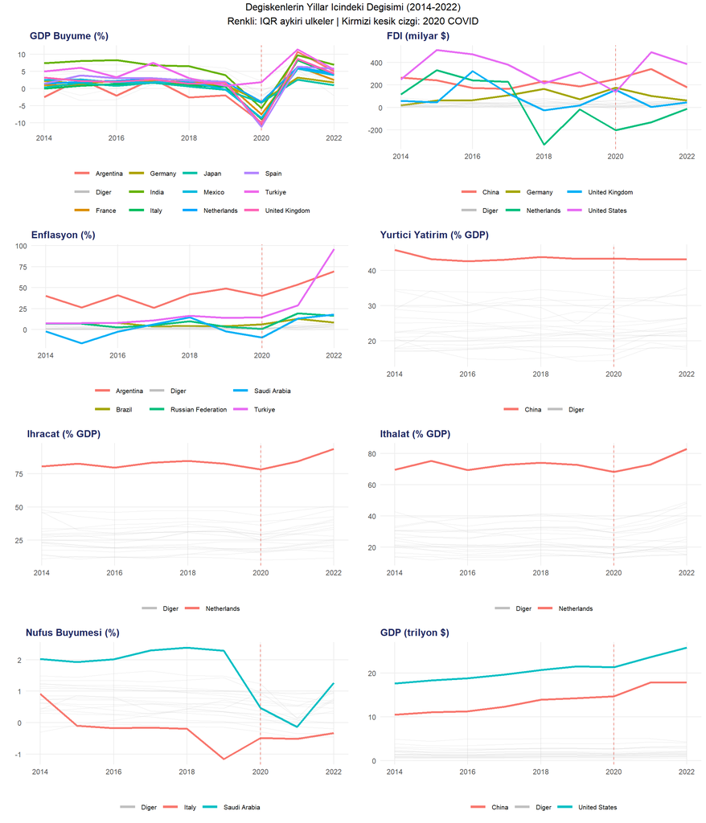

```r
# Her degisken icin zaman serisi — kucuk multiples
degiskenler_gorsel <- c("gdp_growth","fdi","inflation","inv",
                        "export","import_","pop_growth","gdp")

basliklar <- c("GDP Buyume (%)", "FDI (milyar $)",
               "Enflasyon (%)", "Yurtici Yatirim (% GDP)",
               "Ihracat (% GDP)", "Ithalat (% GDP)",
               "Nufus Buyumesi (%)", "GDP (trilyon $)")

panel_gorsel <- panel %>%
  mutate(fdi_g = fdi / 1e9, gdp_t = gdp / 1e12)

donusturulmus <- c("fdi","gdp")

grafikler <- lapply(seq_along(degiskenler_gorsel), function(i) {
  v    <- degiskenler_gorsel[i]
  yvar <- if (v == "fdi") "fdi_g" else if (v == "gdp") "gdp_t" else v
  bas  <- basliklar[i]

  # Aykiri ulkeleri belirle
  q1  <- quantile(panel_gorsel[[yvar]], 0.25, na.rm = TRUE)
  q3  <- quantile(panel_gorsel[[yvar]], 0.75, na.rm = TRUE)
  iqr <- q3 - q1
  aykiri_ulkeler <- panel_gorsel %>%
    filter(.data[[yvar]] < q1 - 1.5*iqr | .data[[yvar]] > q3 + 1.5*iqr) %>%
    pull(country) %>% unique()

  panel_gorsel %>%
    mutate(vurgula = ifelse(country %in% aykiri_ulkeler, country, "Diger")) %>%
    ggplot(aes_string(x = "year", y = yvar, group = "country",
                      color = "vurgula")) +
    geom_line(aes(alpha = vurgula, linewidth = vurgula)) +
    scale_color_manual(
      values = setNames(
        c(scales::hue_pal()(length(aykiri_ulkeler)), "grey75"),
        c(aykiri_ulkeler, "Diger")),
      guide = guide_legend(override.aes = list(linewidth = 1.5))) +
    scale_alpha_manual(values = setNames(
      c(rep(1, length(aykiri_ulkeler)), 0.2),
      c(aykiri_ulkeler, "Diger")), guide = "none") +
    scale_linewidth_manual(values = setNames(
      c(rep(1.2, length(aykiri_ulkeler)), 0.5),
      c(aykiri_ulkeler, "Diger")), guide = "none") +
    geom_vline(xintercept = 2020, linetype = "dashed",
               color = "#E74C3C", linewidth = 0.4, alpha = 0.7) +
    labs(title = bas, x = "", y = "", color = "") +
    theme_minimal(base_size = 11) +
    theme(plot.title   = element_text(face = "bold", color = "#1E2761", size = 12),
          legend.text  = element_text(size = 8),
          legend.position = "bottom",
          legend.key.width = unit(0.8, "cm"),
          panel.grid.minor = element_blank())
})

grid.arrange(grobs = grafikler, ncol = 2,
             top = "Degiskenlerin Yillar Icindeki Degisimi (2014-2022)\nRenkli: IQR aykiri ulkeler | Kirmizi kesik cizgi: 2020 COVID")
```

# 6 Aykiri Deger Analizi

## 6.1 Neden Yapiyoruz?

Aykiri degerler regresyon modelini iki bicimde bozar: **Leverage** (X uzayinda uzak gozlem, tahmin duzlemini kendi yonune ceker) ve **Influence** (katsayi tahminlerini anlamli olcude degistiren gozlem). Bunlari tespit etmeden kurulan bir model yaniltici katsayilar uretir.

## 6.2 IQR Yontemi

```r
degiskenler_iqr <- c("gdp_growth","fdi","inflation","inv",
                     "export","import_","pop_growth","gdp")

iqr_sonuc <- lapply(degiskenler_iqr, function(v) {
  x   <- panel[[v]]
  q1  <- quantile(x, 0.25, na.rm = TRUE)
  q3  <- quantile(x, 0.75, na.rm = TRUE)
  iqr <- q3 - q1
  aykiri <- panel %>%
    filter(.data[[v]] < q1-1.5*iqr | .data[[v]] > q3+1.5*iqr) %>%
    mutate(degisken = v)
  cat(sprintf("[%s] | Aykiri: %d\n", v, nrow(aykiri)))
  aykiri
})
```

```
## [gdp_growth] | Aykiri: 13
## [fdi] | Aykiri: 27
## [inflation] | Aykiri: 22
## [inv] | Aykiri: 9
## [export] | Aykiri: 9
## [import_] | Aykiri: 9
## [pop_growth] | Aykiri: 4
## [gdp] | Aykiri: 18
```

```r
iqr_df <- bind_rows(iqr_sonuc)
```

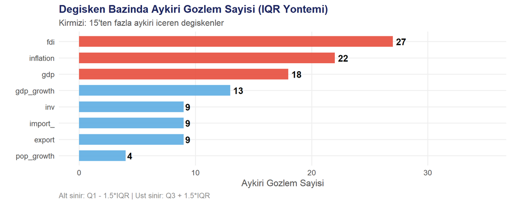

```r
iqr_df %>% count(degisken, name = "n_aykiri") %>%
  ggplot(aes(x = reorder(degisken, n_aykiri),
             y = n_aykiri, fill = n_aykiri > 15)) +
  geom_col(width = 0.65, alpha = 0.9) +
  geom_text(aes(label = n_aykiri), hjust = -0.3, size = 4.5, fontface = "bold") +
  scale_fill_manual(values = c("FALSE"="#5DADE2","TRUE"="#E74C3C"), guide = "none") +
  coord_flip() +
  scale_y_continuous(limits = c(0, 35)) +
  labs(title   = "Degisken Bazinda Aykiri Gozlem Sayisi (IQR Yontemi)",
       subtitle = "Kirmizi: 15'ten fazla aykiri iceren degiskenler",
       x = "", y = "Aykiri Gozlem Sayisi",
       caption = "Alt sinir: Q1 - 1.5*IQR | Ust sinir: Q3 + 1.5*IQR") +
  tema()
```

## 6.3 Cook’s Distance ve Leverage

```r
ols_model  <- lm(gdp_growth ~ fdi + inflation + inv + export +
                   import_ + pop_growth + gdp, data = panel)
n          <- nrow(panel)
k          <- length(coef(ols_model)) - 1
cooks_esik <- 4 / n
lev_esik   <- 2 * (k + 1) / n
panel$cooks_d   <- cooks.distance(ols_model)
panel$leverage  <- hatvalues(ols_model)
panel$std_resid <- rstandard(ols_model)

panel %>%
  filter(cooks_d > cooks_esik & leverage > lev_esik) %>%
  select(country, year, cooks_d, leverage, gdp_growth, inflation) %>%
  arrange(desc(cooks_d)) %>%
  mutate(across(where(is.numeric), ~round(., 3))) %>%
  kable(caption = "Her Ikisi Birden Yuksek: Leverage + Cook's D",
        col.names = c("Ulke","Yil","Cook's D","Leverage",
                      "GDP Buyume","Enflasyon")) %>%
  kable_styling(bootstrap_options = c("striped","hover","condensed"),
                full_width = FALSE, font_size = 13) %>%
  row_spec(1:2, background = "#FDEDEC", bold = TRUE) %>%
  column_spec(3, color = "#E74C3C", bold = TRUE)
```

Her Ikisi Birden Yuksek: Leverage + Cook’s D

| Ulke | Yil | Cook’s D | Leverage | GDP Buyume | Enflasyon |
| --- | --- | --- | --- | --- | --- |
| Turkiye | 2022 | 0.159 | 0.421 | 5.533 | 96.036 |
| Argentina | 2021 | 0.111 | 0.097 | 10.718 | 53.840 |
| Netherlands | 2020 | 0.059 | 0.131 | -3.886 | 1.929 |
| Saudi Arabia | 2022 | 0.052 | 0.123 | 7.486 | 17.984 |
| United States | 2020 | 0.032 | 0.171 | -2.213 | 1.321 |
| Netherlands | 2021 | 0.029 | 0.111 | 6.192 | 2.925 |

**Yorum:** Turkiye 2022 en etkili gozlem. Enflasyonun %96’ya ulasmasi hem Cook’s D hem leverage’i zirveye tasiyor. Argentina 2021’de buyume %10.7 ile ust baz etkisi yaratarak ikinci sirada. Bu iki ulke silinmiyor; robustness check’te anlamsalligi test ediliyor.

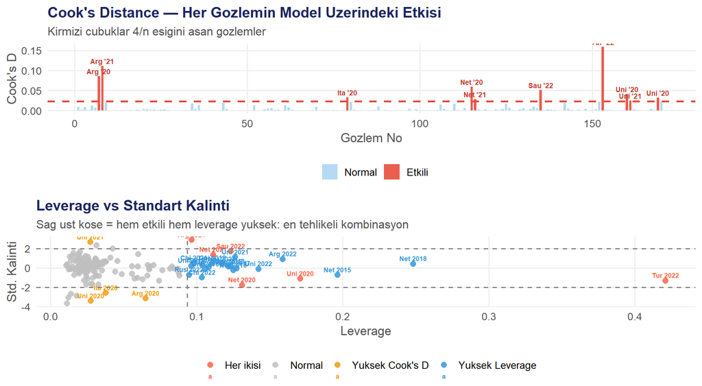

```r
p1 <- ggplot(panel %>% mutate(idx = row_number(),
               etiket = ifelse(cooks_d > cooks_esik,
                               paste0(substr(country,1,3)," '",
                                      substr(year,3,4)), NA)),
             aes(x = idx, y = cooks_d)) +
  geom_col(aes(fill = cooks_d > cooks_esik), width = 0.7, alpha = 0.9) +
  geom_hline(yintercept = cooks_esik, color = "#E74C3C",
             linetype = "dashed", linewidth = 1) +
  geom_text(aes(label = etiket), vjust = -0.4, size = 2.5,
            color = "#C0392B", na.rm = TRUE, fontface = "bold") +
  scale_fill_manual(values = c("FALSE"="#AED6F1","TRUE"="#E74C3C"),
                    labels = c("Normal","Etkili"), name = "") +
  labs(title = "Cook's Distance — Her Gozlemin Model Uzerindeki Etkisi",
       subtitle = "Kirmizi cubuklar 4/n esigini asan gozlemler",
       x = "Gozlem No", y = "Cook's D") +
  tema()

p2 <- ggplot(panel %>% mutate(
               grup = case_when(
                 cooks_d > cooks_esik & leverage > lev_esik ~ "Her ikisi",
                 cooks_d > cooks_esik                       ~ "Yuksek Cook's D",
                 leverage > lev_esik                        ~ "Yuksek Leverage",
                 TRUE                                       ~ "Normal"),
               etiket = ifelse(grup != "Normal",
                               paste(substr(country,1,3), year), NA)),
             aes(x = leverage, y = std_resid, color = grup)) +
  geom_point(size = 2.5, alpha = 0.85) +
  geom_text(aes(label = etiket), vjust = -0.6, size = 2.4,
            na.rm = TRUE, fontface = "bold") +
  geom_hline(yintercept = c(-2,2), linetype = "dashed",
             color = "grey50", linewidth = 0.7) +
  geom_vline(xintercept = lev_esik, linetype = "dashed",
             color = "grey50", linewidth = 0.7) +
  scale_color_manual(
    values = c("Her ikisi"="tomato","Yuksek Cook's D"="#F39C12",
               "Yuksek Leverage"="#3498DB","Normal"="grey75"), name = "") +
  labs(title = "Leverage vs Standart Kalinti",
       subtitle = "Sag ust kose = hem etkili hem leverage yuksek: en tehlikeli kombinasyon",
       x = "Leverage", y = "Std. Kalinti") +
  tema()

grid.arrange(p1, p2, ncol = 1)
```

**Yorum (p1 — Cook’s Distance):** Esigi asan gozlemlerin cogu 2020-2022 araliginda. Bu, COVID ve sonrasi donemin model katsayilarini distort etme potansiyelinin cok yuksek oldugunu gosteriyor. D_COVID, D_RECOVERY gibi kukla degiskenler bu distorsiyonu gidermek icin ekleniyor.

## 6.4 Enflasyon: Yapisal Heterojenlik

Bu iki grafik, analiz metodolojimizin iki onemli kararini birden gorsellestirir.

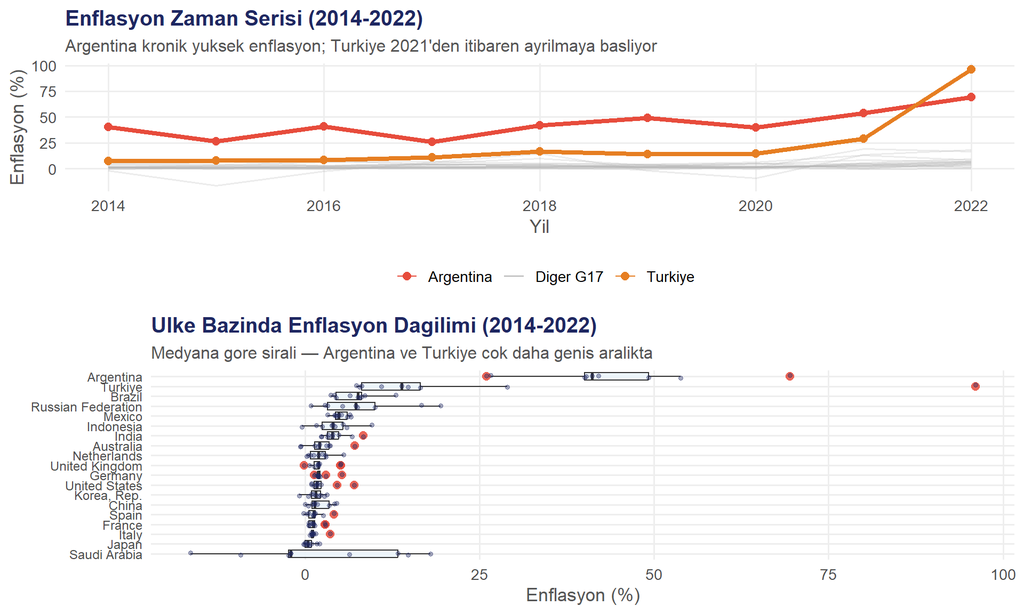

```r
p3 <- panel %>%
  mutate(grup = case_when(country == "Argentina" ~ "Argentina",
                          country == "Turkiye"   ~ "Turkiye",
                          TRUE                   ~ "Diger G17")) %>%
  ggplot(aes(x = year, y = inflation, group = country, color = grup)) +
  geom_line(aes(alpha = grup, linewidth = grup)) +
  geom_point(data = . %>% filter(grup != "Diger G17"), size = 2.5) +
  scale_color_manual(
    values = c("Argentina"="#E74C3C","Turkiye"="#E67E22","Diger G17"="grey70"),
    name = "") +
  scale_alpha_manual(
    values = c("Argentina"=1,"Turkiye"=1,"Diger G17"=0.25), guide = "none") +
  scale_linewidth_manual(
    values = c("Argentina"=1.5,"Turkiye"=1.5,"Diger G17"=0.6), guide = "none") +
  labs(title = "Enflasyon Zaman Serisi (2014-2022)",
       subtitle = "Argentina kronik yuksek enflasyon; Turkiye 2021'den itibaren ayrilmaya basliyor",
       x = "Yil", y = "Enflasyon (%)") +
  tema()

p4 <- ggplot(panel, aes(x = reorder(country, inflation, median, na.rm=TRUE),
                        y = inflation)) +
  geom_boxplot(outlier.color = "#E74C3C", outlier.size = 2.5,
               fill = "#EBF5FB", alpha = 0.85) +
  geom_jitter(width = 0.15, alpha = 0.4, size = 1.3, color = "#1E2761") +
  coord_flip() +
  labs(title = "Ulke Bazinda Enflasyon Dagilimi (2014-2022)",
       subtitle = "Medyana gore sirali — Argentina ve Turkiye cok daha genis aralikta",
       x = "", y = "Enflasyon (%)") +
  tema() + theme(axis.text.y = element_text(size = 9))

grid.arrange(p3, p4, ncol = 1)
```

**Neden Bu Grafik Metodolojimizi Sekillendiriyor?**

Bu grafik iki analitik kararimizin gorsel gerekcesidir: (1) Enflasyon katsayisinin COVID oncesi anlamliligi — normal donemde 17 ulkenin davranisi enflasyon-buyume iliskisini gosteriyor; COVID soklari bunu maskeliyor. (2) Robustness Check I — Argentina ve Turkiye cikarildiginda ayni bulguyu alip almayacagimizi test etmek zorundasiniz, cunku bu iki ulkenin asiri enflasyonu enflasyon katsayisini “gorunur kilabilir” de “yapaymis gibi gosterebilir” de.

**Kutu Grafiginin Analizi (p4):**

Medyana gore sirali kutu grafigi enflasyon heterojenliginin yapısal oldugunu kanitliyor. Argentina’nin kutusunun alt ucu diger tum ulkelerin ust ucundan yuksek. Turkiye ikinci sirada ama aralik cok daha genis (2014’te 8%, 2022’de 96%). Bu yapısal farklilik hem IQR analizinde aykiri sayimini etkiliyor hem de orneklem secimini (Argentina/Turkiye dahil vs. haric) anlamli kiliyor.

# 7 Degisken Donusumleri

## 7.1 Neden FDI Icin IHS Donusumu?

Klasik log donusumu iki ciddi sorunla karsilasir: $\ln(0) = -\infty$ (sifir FDI girisi olan yillar kayboluyor) ve $\ln(\text{negatif})$ tanimsiz. Verimizdeki **8 gozlemde FDI negatif** (net disinvestment): Hollanda 2018: -330 milyar $, Netherlands 2020: -203 milyar $, UK 2018: -25 milyar $ vb. IHS ($\text{sign}(x) \cdot \ln(1+|x|)$) hem negatifleri korur hem olcegi kucultur.

## 7.2 Neden GDP Icin Log Donusumu?

ABD 25 trilyon $ vs Endonezya 1.3 trilyon $ — 20 katlik fark. Log donusumu oran farkini fark farkina cevirerek katsayi yorumunu anlamlastirir.

## 7.3 COVID Kukla Mantigi

```r
panel <- panel %>%
  mutate(
    ihs_fdi      = sign(fdi) * log1p(abs(fdi)),
    ln_gdp       = log(gdp),
    D_COVID      = ifelse(year == 2020, 1, 0),
    D_POST_COVID = ifelse(year %in% c(2021, 2022), 1, 0),
    D_RECOVERY   = ifelse(year == 2021, 1, 0),
    D_2022       = ifelse(year == 2022, 1, 0)
  )

panel %>% filter(fdi < 0) %>%
  select(country, year, fdi, ihs_fdi) %>%
  mutate(fdi_milyar = round(fdi/1e9, 1)) %>%
  select(country, year, fdi_milyar, ihs_fdi) %>%
  kable(caption = "Negatif FDI Gozlemleri ve IHS Sonrasi Degerleri",
        col.names = c("Ulke","Yil","FDI (milyar $)","IHS(FDI)")) %>%
  kable_styling(bootstrap_options = c("striped","hover","condensed"),
                full_width = FALSE, font_size = 13) %>%
  row_spec(which(panel %>% filter(fdi<0) %>% pull(fdi) < -1e11),
           background = "#FDEDEC")
```

Negatif FDI Gozlemleri ve IHS Sonrasi Degerleri

| Ulke | Yil | FDI (milyar $) | IHS(FDI) |
| --- | --- | --- | --- |
| Italy | 2020 | -17.1 | -23.55944 |
| Netherlands | 2018 | -330.3 | -26.52338 |
| Netherlands | 2019 | -18.2 | -23.62580 |
| Netherlands | 2020 | -202.8 | -26.03541 |
| Netherlands | 2021 | -131.5 | -25.60212 |
| Netherlands | 2022 | -12.1 | -23.21449 |
| Russian Federation | 2022 | -39.8 | -24.40713 |
| United Kingdom | 2018 | -25.1 | -23.94436 |

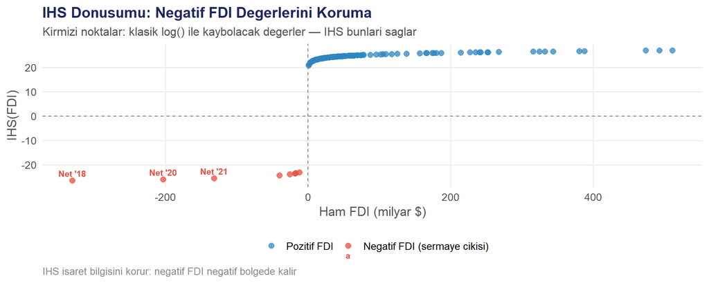

```r
ggplot(panel, aes(x = fdi/1e9, y = ihs_fdi, color = fdi < 0)) +
  geom_point(size = 2.5, alpha = 0.75) +
  geom_vline(xintercept = 0, linetype = "dashed", color = "grey50") +
  geom_hline(yintercept = 0, linetype = "dashed", color = "grey50") +
  geom_text(data = . %>% filter(fdi < -5e10),
            aes(label = paste0(substr(country,1,3)," '",
                               substr(year,3,4))),
            vjust = -0.6, size = 3, fontface = "bold") +
  scale_color_manual(
    values = c("FALSE"="#2E86C1","TRUE"="#E74C3C"),
    labels = c("Pozitif FDI","Negatif FDI (sermaye cikisi)"), name = "") +
  labs(title = "IHS Donusumu: Negatif FDI Degerlerini Koruma",
       subtitle = "Kirmizi noktalar: klasik log() ile kaybolacak degerler — IHS bunlari saglar",
       x = "Ham FDI (milyar $)", y = "IHS(FDI)",
       caption = "IHS isaret bilgisini korur: negatif FDI negatif bolgede kalir") +
  tema()
```

**Yorum:** Kirmizi noktalar (negatif FDI) klasik log donusumunde listeye bile alınamayacakti. IHS ile Hollanda’nin -330 milyar $’i -26.5 IHS birimine donusuyor — sifira indirilmiyor, isaret korunuyor. Bu, FDI’nin ekonomiden kapital cikisinı da olcebilmemizi sagliyor.

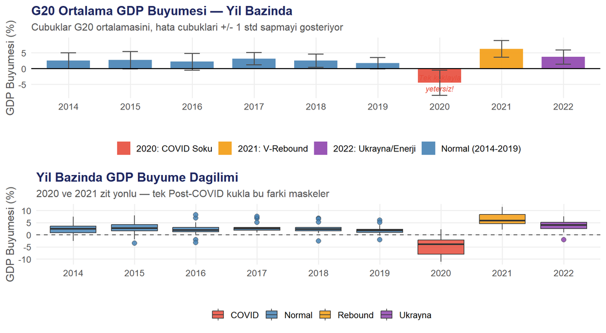

```r
p_bar <- panel %>%
  group_by(year) %>%
  summarise(ort = mean(gdp_growth, na.rm = TRUE),
            std = sd(gdp_growth, na.rm = TRUE), .groups = "drop") %>%
  mutate(donem = case_when(year==2020~"2020: COVID Soku",
                           year==2021~"2021: V-Rebound",
                           year==2022~"2022: Ukrayna/Enerji",
                           TRUE~"Normal (2014-2019)")) %>%
  ggplot(aes(x = factor(year), y = ort, fill = donem)) +
  geom_col(width = 0.7, alpha = 0.9) +
  geom_errorbar(aes(ymin = ort-std, ymax = ort+std),
                width = 0.25, color = "grey30", linewidth = 0.6) +
  geom_hline(yintercept = 0, linewidth = 0.7) +
  annotate("text", x = "2020", y = -4.5, label = "Tek kuklayla\nyetersiz!",
           color = "#E74C3C", size = 3.2, fontface = "italic") +
  scale_fill_manual(
    values = c("2020: COVID Soku"="#E74C3C","2021: V-Rebound"="#F39C12",
               "2022: Ukrayna/Enerji"="#8E44AD","Normal (2014-2019)"="steelblue"),
    name = "") +
  labs(title = "G20 Ortalama GDP Buyumesi — Yil Bazinda",
       subtitle = "Cubuklar G20 ortalamasini, hata cubuklari +/- 1 std sapmayi gosteriyor",
       x = "", y = "GDP Buyumesi (%)") +
  tema()

p_box <- panel %>%
  ggplot(aes(x = factor(year), y = gdp_growth,
             fill = case_when(year==2020~"COVID",year==2021~"Rebound",
                              year==2022~"Ukrayna",TRUE~"Normal"))) +
  geom_boxplot(outlier.shape = 21, outlier.size = 2.5, alpha = 0.85) +
  geom_hline(yintercept = 0, linetype = "dashed",
             color = "grey40", linewidth = 0.7) +
  scale_fill_manual(
    values = c("COVID"="#E74C3C","Rebound"="#F39C12",
               "Ukrayna"="#8E44AD","Normal"="steelblue"), name = "") +
  labs(title = "Yil Bazinda GDP Buyume Dagilimi",
       subtitle = "2020 ve 2021 zit yonlu — tek Post-COVID kukla bu farki maskeler",
       x = "", y = "GDP Buyumesi (%)") +
  tema()

grid.arrange(p_bar, p_box, ncol = 1)
```

# 8 Birim Kok Testleri

## 8.1 Neden Yapiyoruz?

Panel verinin zaman serisi boyutu nedeniyle duragan olmayan seriler **sahte regresyon** yaratabilir. LLC ve Hadri birbirini tamamlayan testlerdir (H0’lar ters).

```r
pdata <- pdata.frame(panel, index = c("country","year"))
cat("Panel balanced mi?", is.pbalanced(pdata), "\n")
```

```
## Panel balanced mi? TRUE
```

```r
degiskenler_bk <- c("gdp_growth","ihs_fdi","inflation","inv",
                    "export","import_","pop_growth","ln_gdp")

llc_p <- sapply(degiskenler_bk, function(v) {
  tryCatch(purtest(pdata[[v]], test="levinlin",
                   exo="intercept", lags=1)$statistic$p.value,
           error = function(e) NA)
})
hadri_p <- sapply(degiskenler_bk, function(v) {
  tryCatch(purtest(pdata[[v]], test="hadri",
                   exo="intercept")$statistic$p.value,
           error = function(e) NA)
})

data.frame(
  Degisken    = degiskenler_bk,
  LLC_p       = round(llc_p, 4),
  LLC_Karar   = ifelse(llc_p < 0.05, "Duragan","Duragan Degil"),
  Hadri_p     = round(hadri_p, 4),
  Hadri_Karar = ifelse(hadri_p < 0.05, "Duragan Degil","Duragan")
) %>%
  kable(caption = "Birim Kok Test Sonuclari",
        col.names = c("Degisken","LLC p","LLC","Hadri p","Hadri")) %>%
  kable_styling(bootstrap_options = c("striped","hover","condensed"),
                full_width = FALSE, font_size = 13)
```

Birim Kok Test Sonuclari

|  | Degisken | LLC p | LLC | Hadri p | Hadri |
| --- | --- | --- | --- | --- | --- |
| gdp_growth.z | gdp_growth | 0.0000 | Duragan | 0.9103 | Duragan |
| ihs_fdi.z | ihs_fdi | 0.0000 | Duragan | 0.0007 | Duragan Degil |
| inflation.z | inflation | 0.0110 | Duragan | 0.0000 | Duragan Degil |
| inv.z | inv | 0.0011 | Duragan | 0.0000 | Duragan Degil |
| export.z | export | 0.0398 | Duragan | 0.0000 | Duragan Degil |
| import_.z | import_ | 0.0000 | Duragan | 0.0000 | Duragan Degil |
| pop_growth.z | pop_growth | 0.8577 | Duragan Degil | 0.0000 | Duragan Degil |
| ln_gdp.z | ln_gdp | 0.5348 | Duragan Degil | 0.0000 | Duragan Degil |

**Yorum:** T=9 kisa panelde LLC ve Hadri cakisan bulgular uretmistir. Bu sorun degil: FE modelinin within donusumu zaten trend bilesenini temizler. **Seviyede devam etmek kisa panel literaturunde standart yaklasimdir** (Baltagi 2008).

# 9 Model Secimi

## 9.1 Pooled OLS vs Sabit Etkiler (F Testi)

Pooled OLS tum ulkeleri ayni sabit terimle modelliyor — Argentina ile Almanya’nin ayni buyume dinamigine sahip oldugunu varsayiyor. Bu ekonomik olarak anlamsiz.

```r
pooled <- plm(gdp_growth ~ ihs_fdi + inflation + inv + export +
                import_ + pop_growth + ln_gdp + D_COVID,
              data = pdata, model = "pooling")
fe     <- plm(gdp_growth ~ ihs_fdi + inflation + inv + export +
                import_ + pop_growth + ln_gdp + D_COVID,
              data = pdata, model = "within")
f_test <- pFtest(fe, pooled)
cat(sprintf("F(%d,%d) = %.4f | p = %.6f\nSonuc: %s\n",
            f_test$parameter[1], f_test$parameter[2],
            f_test$statistic, f_test$p.value,
            ifelse(f_test$p.value < 0.05,
                   "H0 REDDEDILDI — Pooled OLS elendi",
                   "H0 reddedilemedi")))
```

```
## F(18,144) = 3.0036 | p = 0.000133
## Sonuc: H0 REDDEDILDI — Pooled OLS elendi
```

**Gercek Sonuc:** p = 0.0001 — **Pooled OLS elendi.**

## 9.2 Hausman Testi (FE vs RE)

```r
re      <- plm(gdp_growth ~ ihs_fdi + inflation + inv + export +
                 import_ + pop_growth + ln_gdp + D_COVID,
               data = pdata, model = "random")
hausman <- phtest(fe, re)
cat(sprintf("Chi2(%d) = %.3f | p = %.6f\nSonuc: %s\n",
            hausman$parameter, hausman$statistic, hausman$p.value,
            ifelse(hausman$p.value < 0.05,
                   "H0 REDDEDILDI — RE tutarsiz, FE kullan",
                   "H0 reddedilemedi")))
```

```
## Chi2(8) = 26.091 | p = 0.001013
## Sonuc: H0 REDDEDILDI — RE tutarsiz, FE kullan
```

**Gercek Sonuc:** p = 0.001 — **RE tutarsiz. FE kesin secim.**

**Neden FE?** Argentina’nin kronik enflasyon gecmisi hem FDI’yi hem buyumeyi etkiliyor — ulke ozgul faktorler aciklayicilarla iliskili. RE bunu gormezden gelir, sapmalı tahmin uretir.

# 10 Varsayim Testleri

```r
bp_test  <- bptest(fe)
woo_test <- pbgtest(fe)
cd_test  <- pcdtest(fe, test = "cd")

data.frame(
  Test       = c("Breusch-Pagan (Degisen Varyans)",
                 "Wooldridge (Otokorelasyon)",
                 "Pesaran CD (Yatay Kesit Bag.)"),
  Istatistik = c(sprintf("BP = %.3f",  bp_test$statistic),
                 sprintf("chi2 = %.3f",woo_test$statistic),
                 sprintf("z = %.3f",   cd_test$statistic)),
  p_degeri   = c(sprintf("%.5f", bp_test$p.value),
                 sprintf("%.5f", woo_test$p.value),
                 sprintf("%.1e", cd_test$p.value)),
  Karar      = c("VAR ***","VAR **","VAR ***"),
  Etki       = c("SE'ler kucuk, yanlis t-stat",
                 "SE'ler kucuk, yanlis t-stat",
                 "Kuresel sok modele yansimiyor")
) %>%
  kable(caption = "Varsayim Testleri: Uc Ihlal Ayni Anda Mevcut") %>%
  kable_styling(bootstrap_options = c("striped","hover","condensed","bordered"),
                full_width = FALSE, font_size = 13) %>%
  column_spec(4, color = "#E74C3C", bold = TRUE) %>%
  row_spec(0, background = "#1E2761", color = "white")
```

Varsayim Testleri: Uc Ihlal Ayni Anda Mevcut

| Test | Istatistik | p_degeri | Karar | Etki |
| --- | --- | --- | --- | --- |
| Breusch-Pagan (Degisen Varyans) | BP = 29.157 | 0.00030 | VAR *** | SE’ler kucuk, yanlis t-stat |
| Wooldridge (Otokorelasyon) | chi2 = 19.736 | 0.01961 | VAR ** | SE’ler kucuk, yanlis t-stat |
| Pesaran CD (Yatay Kesit Bag.) | z = 4.531 | 5.9e-06 | VAR *** | Kuresel sok modele yansimiyor |

**Neden Driscoll-Kraay?** Tek basina uc ihlali birden cozen yontem. White SE sadece degisen varyansi, Newey-West otokorelasyonu, Cluster SE yatay kesit bagimsizligini ele almaz. DK hepsini birden cozer.

# 11 Ana Modeller

## 11.1 Uc Spesifikasyon Mantigi

| Model | Kukla Degiskenler | Mantik |
| --- | --- | --- |
| M1 | D_COVID (2020) | Sadece COVID yilini kontrol et |
| M2 | D_COVID + D_POST_COVID (2021+2022 birlikte) | Soku 2020 ayri, sonrasini birlikte |
| M3 | D_COVID + D_RECOVERY + D_2022 (hepsi ayri) | Her yilin kendi ekonomik gercekligi |

```r
fe_m1    <- plm(gdp_growth ~ ihs_fdi + inflation + inv + export +
                  import_ + pop_growth + ln_gdp + D_COVID,
                data = pdata, model = "within")
fe_m1_dk <- coeftest(fe_m1, vcov = vcovSCC(fe_m1, type="HC3", cluster="group"))

fe_m2    <- plm(gdp_growth ~ ihs_fdi + inflation + inv + export +
                  import_ + pop_growth + ln_gdp + D_COVID + D_POST_COVID,
                data = pdata, model = "within")
fe_m2_dk <- coeftest(fe_m2, vcov = vcovSCC(fe_m2, type="HC3", cluster="group"))

fe_m3    <- plm(gdp_growth ~ ihs_fdi + inflation + inv + export +
                  import_ + pop_growth + ln_gdp + D_COVID + D_RECOVERY + D_2022,
                data = pdata, model = "within")
fe_m3_dk <- coeftest(fe_m3, vcov = vcovSCC(fe_m3, type="HC3", cluster="group"))

r2_m1 <- round(summary(fe_m1)$r.squared["rsq"], 3)
r2_m2 <- round(summary(fe_m2)$r.squared["rsq"], 3)
r2_m3 <- round(summary(fe_m3)$r.squared["rsq"], 3)
cat("M1 R2:", r2_m1, "\nM2 R2:", r2_m2, "\nM3 R2:", r2_m3, "\n")
```

```
## M1 R2: 0.635
## M2 R2: 0.68
## M3 R2: 0.706
```

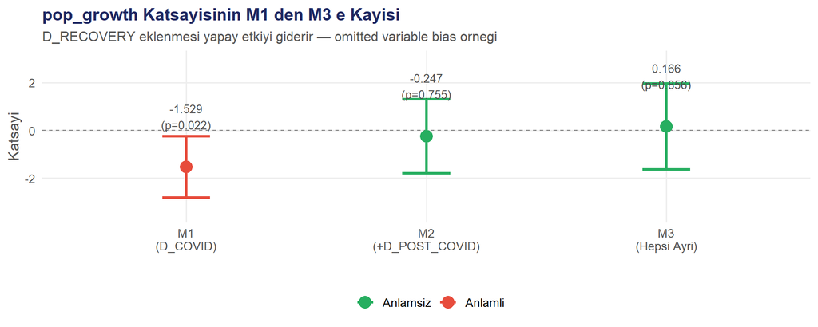

```r
pop_df <- data.frame(
  model   = c("M1\n(D_COVID)","M2\n(+D_POST_COVID)","M3\n(Hepsi Ayri)"),
  katsayi = c(fe_m1_dk["pop_growth","Estimate"],
               fe_m2_dk["pop_growth","Estimate"],
               fe_m3_dk["pop_growth","Estimate"]),
  se      = c(fe_m1_dk["pop_growth","Std. Error"],
               fe_m2_dk["pop_growth","Std. Error"],
               fe_m3_dk["pop_growth","Std. Error"]),
  p       = c(fe_m1_dk["pop_growth","Pr(>|t|)"],
               fe_m2_dk["pop_growth","Pr(>|t|)"],
               fe_m3_dk["pop_growth","Pr(>|t|)"])
) %>%
  mutate(alt = katsayi - 1.96*se, ust = katsayi + 1.96*se,
         model = factor(model, levels = model))

ggplot(pop_df, aes(x = model, y = katsayi, color = p < 0.05)) +
  geom_hline(yintercept = 0, linetype = "dashed", color = "grey50") +
  geom_errorbar(aes(ymin=alt, ymax=ust), width=0.2, linewidth=1.2) +
  geom_point(size = 5) +
  geom_text(aes(label = sprintf("%.3f\n(p=%.3f)", katsayi, p)),
            vjust = -1.5, size = 3.5, color = "grey30") +
  scale_color_manual(values = c("TRUE"="#E74C3C","FALSE"="#27AE60"),
                     labels = c("Anlamsiz","Anlamli"), name = "") +
  ylim(-3.5, 3.0) +
  labs(title = "pop_growth Katsayisinin M1 den M3 e Kayisi",
       subtitle = "D_RECOVERY eklenmesi yapay etkiyi giderir — omitted variable bias ornegi",
       x = "", y = "Katsayi") +
  tema()
```

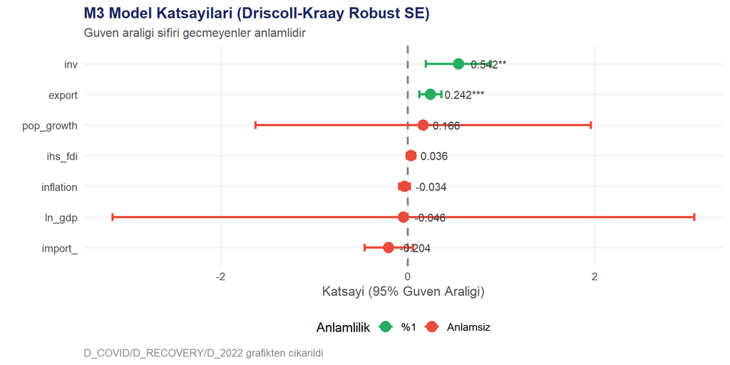

```r
df_m3 <- data.frame(
  degisken = rownames(fe_m3_dk),
  katsayi  = fe_m3_dk[,"Estimate"],
  se       = fe_m3_dk[,"Std. Error"],
  p        = fe_m3_dk[,"Pr(>|t|)"]
) %>%
  filter(!degisken %in% c("D_COVID","D_RECOVERY","D_2022")) %>%
  mutate(alt=katsayi-1.96*se, ust=katsayi+1.96*se,
         anlamli=case_when(p<0.01~"%1",p<0.05~"%5",p<0.10~"%10",TRUE~"Anlamsiz"),
         anlamli=factor(anlamli,levels=c("%1","%5","%10","Anlamsiz")),
         etiket=sprintf("%.3f%s",katsayi,stars(p)))

ggplot(df_m3, aes(x=reorder(degisken,katsayi),y=katsayi,color=anlamli)) +
  geom_hline(yintercept=0,linetype="dashed",color="grey50",linewidth=0.9) +
  geom_errorbar(aes(ymin=alt,ymax=ust),width=0.25,linewidth=1.1) +
  geom_point(size=5) +
  geom_text(aes(label=etiket),hjust=-0.35,size=3.8,color="grey25") +
  scale_color_manual(
    values=c("%1"="#27AE60","%5"="#2E86C1","%10"="#F39C12","Anlamsiz"="#E74C3C"),
    name="Anlamlilik") +
  coord_flip() +
  labs(title="M3 Model Katsayilari (Driscoll-Kraay Robust SE)",
       subtitle="Guven araligi sifiri gecmeyenler anlamlidir",
       x="",y="Katsayi (95% Guven Araligi)",
       caption="D_COVID/D_RECOVERY/D_2022 grafikten cikarildi") +
  tema()
```

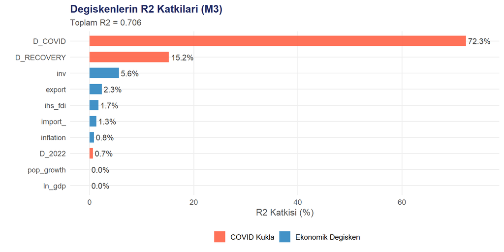

```r
degiskenler_m3 <- c("ihs_fdi","inflation","inv","export","import_",
                    "pop_growth","ln_gdp","D_COVID","D_RECOVERY","D_2022")

katki_m3 <- lapply(degiskenler_m3, function(v) {
  kalan  <- setdiff(degiskenler_m3, v)
  formul <- as.formula(paste("gdp_growth ~", paste(kalan, collapse="+")))
  fe_eks <- plm(formul, data=pdata, model="within")
  data.frame(degisken=v,
             katki_r2=max(r2_m3-summary(fe_eks)$r.squared["rsq"], 0))
}) %>% bind_rows() %>%
  mutate(katki_pct = katki_r2/sum(katki_r2)*100,
         tur = ifelse(degisken %in% c("D_COVID","D_RECOVERY","D_2022"),
                      "COVID Kukla","Ekonomik Degisken")) %>%
  arrange(desc(katki_pct))

ggplot(katki_m3, aes(x=reorder(degisken,katki_pct),y=katki_pct,fill=tur)) +
  geom_col(width=0.65, alpha=0.9) +
  geom_text(aes(label=sprintf("%.1f%%",katki_pct)),hjust=-0.1,size=4,color="grey25") +
  scale_fill_manual(values=c("COVID Kukla"="tomato","Ekonomik Degisken"="#2E86C1"),
                    name="") +
  coord_flip() +
  scale_y_continuous(limits=c(0,75)) +
  labs(title="Degiskenlerin R2 Katkilari (M3)",
       subtitle=sprintf("Toplam R2 = %.3f", r2_m3),
       x="",y="R2 Katkisi (%)") +
  tema()
```

# 12 COVID Oncesi Model (2014-2019)

## 12.1 Neden Ayri Analiz?

```r
panel_pre <- panel %>% filter(year <= 2019)
pdata_pre <- pdata.frame(panel_pre, index=c("country","year"))
cat("Gozlem sayisi:", nrow(panel_pre), "(19 ulke x 6 yil)\n")
```

```
## Gozlem sayisi: 114 (19 ulke x 6 yil)
```

```r
fe_pre    <- plm(gdp_growth ~ ihs_fdi + inflation + inv + export +
                   import_ + pop_growth + ln_gdp,
                 data=pdata_pre, model="within")
fe_pre_dk <- coeftest(fe_pre, vcov=vcovSCC(fe_pre,type="HC3",cluster="group"))
print(fe_pre_dk)
```

```
##
## t test of coefficients:
##
##              Estimate Std. Error t value  Pr(>|t|)
## ihs_fdi     0.0082877  0.0076929  1.0773 0.2842838
## inflation  -0.1790207  0.0726419 -2.4644 0.0156667 *
## inv         0.3317464  0.1778893  1.8649 0.0655279 .
## export      0.2235469  0.0565788  3.9511 0.0001566 ***
## import_    -0.2654438  0.0772586 -3.4358 0.0009037 ***
## pop_growth  0.1543427  0.4325085  0.3569 0.7220549
## ln_gdp      0.9820472  1.7759809  0.5530 0.5816925
## ---
## Signif. codes:  0 '***' 0.001 '**' 0.01 '*' 0.05 '.' 0.1 ' ' 1
```

```r
r2_pre <- round(summary(fe_pre)$r.squared["rsq"], 3)
cat(sprintf("\nR-kare: %.3f\n", r2_pre))
```

```
##
## R-kare: 0.256
```

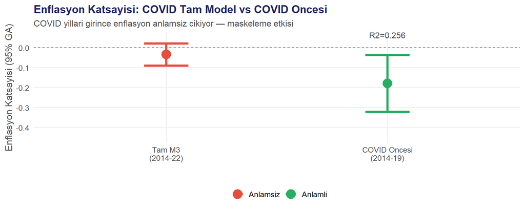

```r
df_enf <- data.frame(
  model   = c("Tam M3\n(2014-22)","COVID Oncesi\n(2014-19)"),
  katsayi = c(fe_m3_dk["inflation","Estimate"],
               fe_pre_dk["inflation","Estimate"]),
  se      = c(fe_m3_dk["inflation","Std. Error"],
               fe_pre_dk["inflation","Std. Error"]),
  p       = c(fe_m3_dk["inflation","Pr(>|t|)"],
               fe_pre_dk["inflation","Pr(>|t|)"]),
  r2      = c(r2_m3, r2_pre)
) %>%
  mutate(alt=katsayi-1.96*se, ust=katsayi+1.96*se,
         model=factor(model,levels=model))

ggplot(df_enf, aes(x=model, y=katsayi, color=p<0.05)) +
  geom_hline(yintercept=0, linetype="dashed", color="grey50") +
  geom_errorbar(aes(ymin=alt,ymax=ust),width=0.2,linewidth=1.5) +
  geom_point(size=6) +
  geom_text(aes(label=sprintf("beta=%.3f\np=%.3f\nR2=%.3f",katsayi,p,r2)),
            vjust=-1.5, size=4, color="grey30") +
  scale_color_manual(values=c("TRUE"="#27AE60","FALSE"="#E74C3C"),
                     labels=c("Anlamsiz","Anlamli"), name="") +
  ylim(-0.45, 0.05) +
  labs(title="Enflasyon Katsayisi: COVID Tam Model vs COVID Oncesi",
       subtitle="COVID yillari girince enflasyon anlamsiz cikiyor — maskeleme etkisi",
       x="", y="Enflasyon Katsayisi (95% GA)") +
  tema()
```

**Yorum:** COVID oncesinde enflasyon p=0.016 ile anlamli ve katsayi -0.179: normal koşullarda enflasyon 1 puan artiginda buyume 0.18 puan dusuyor. Tam modelde ise ayni degisken anlamsiz. Bu olcu hatasi degil — COVID donemine ait devasa negatif (2020) ve pozitif (2021) buyume varyansı, daha kucuk enflasyon etkisini “gomuyor.” Bulgumuz: COVID maskesinin kaldirilmasi enflasyonu ortaya cikariyor.

# 13 Kapsamli Karsilastirma Tablolari

```r
nm_a <- c("M1 (D_COVID)","M2 (+D_POST_COVID)","M3 (Hepsi Ayri)")
tablo_a_long <- lapply(seq_along(nm_a), function(i) {
  model_satirlari(list(fe_m1_dk,fe_m2_dk,fe_m3_dk)[[i]], nm_a[i])
}) %>% bind_rows()

tablo_a_wide <- tablo_a_long %>%
  select(degisken,model,goster) %>%
  pivot_wider(names_from=model,values_from=goster) %>%
  mutate(across(everything(),~ifelse(is.na(.),"-",.)))

tablo_vars_tam <- c("ihs_fdi","inflation","inv","export","import_",
                    "pop_growth","ln_gdp","D_COVID","D_POST_COVID",
                    "D_RECOVERY","D_2022")
satir_a <- intersect(tablo_vars_tam, unique(tablo_a_long$degisken))
tablo_a_wide <- tablo_a_wide[match(satir_a, tablo_a_wide$degisken),]

r2_a <- data.frame(
  degisken            = c("","R2","N","Yillar"),
  "M1 (D_COVID)"      = c("",sprintf("%.3f",r2_m1),nrow(panel),"2014-2022"),
  "M2 (+D_POST_COVID)"= c("",sprintf("%.3f",r2_m2),nrow(panel),"2014-2022"),
  "M3 (Hepsi Ayri)"   = c("",sprintf("%.3f",r2_m3),nrow(panel),"2014-2022"),
  check.names=FALSE)
colnames(r2_a) <- colnames(tablo_a_wide)
tablo_a_final  <- bind_rows(tablo_a_wide, r2_a)

kable(tablo_a_final,
      caption="Tablo A - Tam Donem: COVID Kukla Spesifikasyonlari (2014-2022)",
      align=c("l",rep("c",3)), col.names=colnames(tablo_a_final)) %>%
  kable_styling(bootstrap_options=c("striped","hover","condensed","bordered"),
                full_width=FALSE, font_size=13) %>%
  row_spec(which(tablo_a_final$degisken %in% c("ihs_fdi","inflation")),
           background="#FEF9E7") %>%
  row_spec(nrow(tablo_a_wide)+1, bold=TRUE,
           extra_css="border-top: 2px solid #333;") %>%
  footnote(general="Parantez icinde DK robust SE. *** p<0.001 ** p<0.01 * p<0.05 . p<0.10",
           general_title="Not:")
```

Tablo A - Tam Donem: COVID Kukla Spesifikasyonlari (2014-2022)

degisken

M1 (D_COVID)

M2 (+D_POST_COVID)

M3 (Hepsi Ayri)

ihs_fdi

0.039 (0.025)

0.038 (0.028)

0.036 (0.022)

inflation

-0.036 (0.060)

-0.047* (0.023)

-0.034 (0.028)

inv

0.729*** (0.208)

0.634*** (0.188)

0.542** (0.177)

export

0.379** (0.127)

0.255*** (0.062)

0.242*** (0.060)

import_

-0.284. (0.152)

-0.334* (0.137)

-0.204 (0.132)

pop_growth

-1.529* (0.658)

-0.247 (0.791)

0.166 (0.916)

ln_gdp

1.991 (1.536)

-1.968 (1.363)

-0.046 (1.588)

D_COVID

-7.061*** (0.875)

-6.891*** (0.921)

-6.560*** (0.947)

D_POST_COVID

2.737*** (0.607)

D_RECOVERY

3.614*** (0.679)

D_2022

0.968 (0.827)

R2

0.635

0.680

0.706

N

171

171

171

Yillar

2014-2022

2014-2022

2014-2022

Not:

Parantez icinde DK robust SE. *** p<0.001 ** p<0.01 * p<0.05 . p<0.10

**Yorum:** M1’den M3’e gecerken uc kritik degisiklik: (1) `pop_growth` -1.53* (anlamli) → +0.17 (anlamsiz) — D_RECOVERY etkiyi emdi, (2) R2: 0.635 → 0.706 — her yili ayirmanin modeli iyilestirdigi kanitlandi, (3) D_2022 anlamsiz cikti — 2022 Ukrayna krizinin G20 ortalamasinda anlamli bir etki birakmadigi goruldu.

```r
# Rob modelleri: 19 - 2 = 17 ulke
panel_rob     <- panel     %>% filter(!country %in% c("Argentina","Turkiye"))
panel_rob_pre <- panel_rob %>% filter(year <= 2019)
pdata_rob     <- pdata.frame(panel_rob,     index=c("country","year"))
pdata_rob_pre <- pdata.frame(panel_rob_pre, index=c("country","year"))

fe_rob <- plm(gdp_growth ~ ihs_fdi+inflation+inv+export+
                import_+pop_growth+ln_gdp+D_COVID+D_RECOVERY+D_2022,
              data=pdata_rob, model="within")
fe_rob_dk <- coeftest(fe_rob, vcov=vcovSCC(fe_rob,type="HC3",cluster="group"))

fe_rob_pre <- plm(gdp_growth ~ ihs_fdi+inflation+inv+export+
                    import_+pop_growth+ln_gdp,
                  data=pdata_rob_pre, model="within")
fe_rob_pre_dk <- coeftest(fe_rob_pre,
                          vcov=vcovSCC(fe_rob_pre,type="HC3",cluster="group"))

# R2 degerlerini dogrudan hesapla — bos birakmiyoruz
r2_rob     <- round(summary(fe_rob)$r.squared["rsq"],     3)
r2_rob_pre <- round(summary(fe_rob_pre)$r.squared["rsq"], 3)

cat("Rob-Tam R2:", r2_rob, "| N:", nrow(panel_rob), "(17 ulke x 9 yil)\n")
```

```
## Rob-Tam R2: 0.73 | N: 153 (17 ulke x 9 yil)
```

```r
cat("Rob-Pre R2:", r2_rob_pre, "| N:", nrow(panel_rob_pre), "(17 ulke x 6 yil)\n")
```

```
## Rob-Pre R2: 0.11 | N: 102 (17 ulke x 6 yil)
```

```r
tablo_vars_b <- c("ihs_fdi","inflation","inv","export","import_",
                  "pop_growth","ln_gdp","D_COVID","D_RECOVERY","D_2022")

nm_b <- c("M3 Tam (2014-22)","Pre-COVID (2014-19)",
          "Rob-Tam (17 ulke)","Rob-Pre (17 ulke)")
tablo_b_long <- lapply(seq_along(nm_b), function(i) {
  model_satirlari(list(fe_m3_dk,fe_pre_dk,fe_rob_dk,fe_rob_pre_dk)[[i]], nm_b[i])
}) %>% bind_rows()

tablo_b_wide <- tablo_b_long %>%
  select(degisken,model,goster) %>%
  pivot_wider(names_from=model,values_from=goster) %>%
  mutate(across(everything(),~ifelse(is.na(.),"-",.)))

satir_b <- intersect(tablo_vars_b, unique(tablo_b_long$degisken))
tablo_b_wide <- tablo_b_wide[match(satir_b, tablo_b_wide$degisken),]

# R2 ARTIK HESAPLANARAK DOLDURULUYOR
r2_b <- data.frame(
  degisken            = c("","R2","N","Yillar"),
  "M3 Tam (2014-22)"  = c("",sprintf("%.3f",r2_m3),
                           as.character(nrow(panel)),"2014-2022"),
  "Pre-COVID (2014-19)"= c("",sprintf("%.3f",r2_pre),
                           as.character(nrow(panel_pre)),"2014-2019"),
  "Rob-Tam (17 ulke)" = c("",sprintf("%.3f",r2_rob),
                           as.character(nrow(panel_rob)),"2014-2022"),
  "Rob-Pre (17 ulke)" = c("",sprintf("%.3f",r2_rob_pre),
                           as.character(nrow(panel_rob_pre)),"2014-2019"),
  check.names=FALSE)
colnames(r2_b)  <- colnames(tablo_b_wide)
tablo_b_final   <- bind_rows(tablo_b_wide, r2_b)

kable(tablo_b_final,
      caption="Tablo B - Ana Bulgular: Tam / COVID Oncesi / Robustness",
      align=c("l",rep("c",4)), col.names=colnames(tablo_b_final)) %>%
  kable_styling(bootstrap_options=c("striped","hover","condensed","bordered"),
                full_width=FALSE, font_size=13) %>%
  column_spec(2, bold=TRUE, background="#EBF5FB") %>%
  column_spec(3, bold=TRUE, background="#EAFAF1") %>%
  row_spec(which(tablo_b_final$degisken %in% c("ihs_fdi","inflation")),
           background="#FEF9E7",
           extra_css="border-left: 3px solid #E74C3C;") %>%
  row_spec(nrow(tablo_b_wide)+1, bold=TRUE,
           extra_css="border-top: 2px solid #333;") %>%
  footnote(general="Mavi=Ana model, Yesil=COVID oncesi. Ana aciklayicilar kirmizi kenarla isaretlendi.",
           general_title="Not:")
```

Tablo B - Ana Bulgular: Tam / COVID Oncesi / Robustness

degisken

M3 Tam (2014-22)

Pre-COVID (2014-19)

Rob-Tam (17 ulke)

Rob-Pre (17 ulke)

ihs_fdi

0.036 (0.022)

0.008 (0.008)

0.031 (0.023)

0.009 (0.008)

inflation

-0.034 (0.028)

-0.179* (0.073)

-0.072 (0.082)

-0.110 (0.067)

inv

0.542** (0.177)

0.332. (0.178)

0.326* (0.164)

0.200. (0.103)

export

0.242*** (0.060)

0.224*** (0.057)

0.262** (0.086)

0.206* (0.082)

import_

-0.204 (0.132)

-0.265*** (0.077)

-0.146 (0.119)

-0.171 (0.113)

pop_growth

0.166 (0.916)

0.154 (0.433)

0.098 (0.826)

0.125 (0.383)

ln_gdp

-0.046 (1.588)

0.982 (1.776)

-0.200 (1.479)

0.070 (2.051)

D_COVID

-6.560*** (0.947)

-6.592*** (1.200)

D_RECOVERY

3.614*** (0.679)

3.230*** (0.633)

D_2022

0.968 (0.827)

0.676 (0.857)

R2

0.706

0.256

0.730

0.110

N

171

114

153

102

Yillar

2014-2022

2014-2019

2014-2022

2014-2019

Not:

Mavi=Ana model, Yesil=COVID oncesi. Ana aciklayicilar kirmizi kenarla isaretlendi.

```r
ana_deg <- c("ihs_fdi","inflation","inv","export","import_",
             "pop_growth","ln_gdp")

tablo_c <- data.frame(
  Degisken = ana_deg,
  M1 = sapply(ana_deg, cek, ct=fe_m1_dk),
  M2 = sapply(ana_deg, cek, ct=fe_m2_dk),
  M3 = sapply(ana_deg, cek, ct=fe_m3_dk),
  check.names=FALSE)

kukla_satirlari <- data.frame(
  Degisken = c("-------","D_COVID (2020)",
               "D_POST_COVID (2021-22)","D_RECOVERY (2021)",
               "D_2022 (2022)","-------","R2"),
  M1 = c("",cek(fe_m1_dk,"D_COVID"),"-","-","-","",
         sprintf("%.3f",r2_m1)),
  M2 = c("",cek(fe_m2_dk,"D_COVID"),
         cek(fe_m2_dk,"D_POST_COVID"),"-","-","",
         sprintf("%.3f",r2_m2)),
  M3 = c("",cek(fe_m3_dk,"D_COVID"),"-",
         cek(fe_m3_dk,"D_RECOVERY"),cek(fe_m3_dk,"D_2022"),"",
         sprintf("%.3f",r2_m3)),
  check.names=FALSE)

tablo_c_final <- bind_rows(tablo_c, kukla_satirlari)

kable(tablo_c_final,
      caption="Tablo C - Kukla Eklendikce Ekonomik Katsayilardaki Degisim",
      col.names=c("Degisken","M1 (D_COVID)","M2 (+D_POST_COVID)",
                  "M3 (Hepsi Ayri)"),
      align=c("l","c","c","c")) %>%
  kable_styling(bootstrap_options=c("striped","hover","condensed","bordered"),
                full_width=FALSE, font_size=13) %>%
  row_spec(which(tablo_c_final$Degisken %in% c("ihs_fdi","inflation")),
           background="#FEF9E7") %>%
  row_spec(which(tablo_c_final$Degisken %in%
                   c("D_COVID (2020)","D_POST_COVID (2021-22)",
                     "D_RECOVERY (2021)","D_2022 (2022)")),
           background="#FDEDEC", bold=TRUE) %>%
  footnote(general="*** p<0.001 ** p<0.01 * p<0.05 . p<0.10",
           general_title="Not:")
```

Tablo C - Kukla Eklendikce Ekonomik Katsayilardaki Degisim

Degisken

M1 (D_COVID)

M2 (+D_POST_COVID)

M3 (Hepsi Ayri)

ihs_fdi

ihs_fdi

0.039

0.038

0.036

inflation

inflation

-0.036

-0.047*

-0.034

inv

inv

0.729***

0.634***

0.542**

export

export

0.379**

0.255***

0.242***

import_

import_

-0.284.

-0.334*

-0.204

pop_growth

pop_growth

-1.529*

-0.247

0.166

ln_gdp

ln_gdp

1.991

-1.968

-0.046

——-

…9

D_COVID (2020)

-7.061***

-6.891***

-6.560***

…10

D_POST_COVID (2021-22)

2.737***

…11

D_RECOVERY (2021)

3.614***

…12

D_2022 (2022)

0.968

…13

——-

…14

R2

0.635

0.680

0.706

Not:

*** p<0.001 ** p<0.01 * p<0.05 . p<0.10